# ND025 Capstone project - Facies (Kinds of lithology rocks)

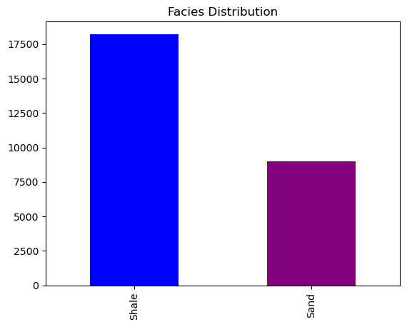

```python
"""
Plot a bar graph to show how the Facies are distributed.
"""
facies = df["Litho_Facies_Label"] \
            .value_counts() \
            .sort_index() \
            .sort_values(ascending=False) # sort by descending

facies.plot(
    kind="bar",
    color=
        ["blue",
         "purple"
    ],
    title="Facies Distribution"
)

plt.show()
```

```python
"""
Well logs plot
"""
f_labels = ["Shale", "Sand"]
f_colors = ["#d05430", "#36b8e3"]


def log_plot_facies(logs, facies_colors):

    # To sort log by depth
    logs = logs.sort_values(by="Depth")

    facies_cmap = colors.ListedColormap(
            facies_colors[0:len(facies_colors)+1],
        "indexed"
    )

    ztop = 3100
    zbot = 3800

    cluster = np.repeat(
        np.expand_dims(
            df["Litho_Facies"].values,
            1
        ),
        100,
        1
    )

    f, ax = plt.subplots(
        nrows=1,
        ncols=6,
        figsize=(8, 12)
    )
    ax[0].plot(
        df.GR,
        df.Depth,
        "-g"
    )
    ax[1].plot(
        df.VCL,
        df.Depth,
        "-"
    )
    ax[2].plot(
        df.NPHI,
        df.Depth,
        "-",
        color="0.5"
    )
    ax[3].plot(
        df.RHOB,
        df.Depth,
        "-",
        color="r"
    )
    ax[4].plot(
        df.DT,
        df.Depth,
        "-",
        color="purple"
    )

    im = ax[5].imshow(
        cluster,
        interpolation="none",
        aspect="auto",
        cmap=facies_cmap,
        vmin=0,
        vmax=1
    )

    divider = make_axes_locatable(ax[5])
    cax = divider.append_axes(
        "right",
        size="20%",
        pad=0.05
    )
    cbar = plt.colorbar(
        im,
        cax=cax
    )
    cbar.set_label(
        (18*" ").join([" Sand ", " Shale "])
    )
    cbar.set_ticks(
        range(0,1))
    cbar.set_ticklabels("")

    for i in range(len(ax)-1):
        ax[i].set_ylim(ztop,zbot)
        ax[i].invert_yaxis()
        ax[i].grid()
        ax[i].locator_params(
            axis="x",
            nbins=3
        )

    ax[0].set_xlabel("GR")
    ax[0].set_xlim(0, 150)

    ax[1].set_xlabel("VCL")
    ax[1].set_xlim(0, 1)

    ax[2].set_xlabel("NPHI")
    ax[2].set_xlim(0.1, 0.3)

    ax[3].set_xlabel("RHOB")
    ax[3].set_xlim(2, 3)

    ax[4].set_xlabel("DT")
    ax[4].set_xlim(60, 150)

    ax[5].set_xlabel("Litho_Facies")
    ax[5].set_xlim(0, 1)

    ax[1].set_yticklabels([])
    ax[2].set_yticklabels([])
    ax[3].set_yticklabels([])
    ax[4].set_yticklabels([])
    ax[5].set_yticklabels([])
    ax[5].set_xticklabels([])
```

[figure not shown]

```python
log_plot_facies(
    df[df["Well Name"] == "1"],
    f_colors
)
```

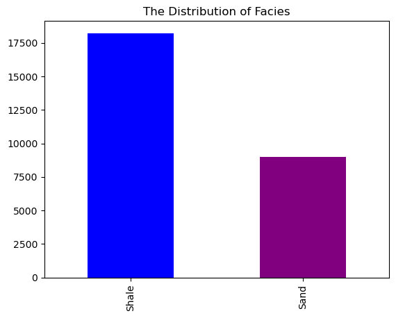

```python
"""
Facies Distribution
"""
facies = df["Litho_Facies_Label"] \
    .value_counts() \
    .sort_index() \
    .sort_values(ascending=False) # sort by descending

facies.plot(
    kind="bar",
    color=[
        "blue",
        "purple"
    ],
    title="The Distribution of Facies"
)

plt.show()
```

### 1.2 Data exploration

```python
"""
To set the index by Depth
"""
df.set_index(
    "Depth",
    inplace=True
)
```

```python
"""
To group by Well Name
"""
df.groupby("Well Name").count()
```

| Well Name | Litho_Facies | Formation | GR | VCL | NPHI | RHOB | DT | FACIES | PHI | Litho_Facies_Label |
| --- | --- | --- | --- | --- | --- | --- | --- | --- | --- | --- |
| 1 | 6649 | 6649 | 6649 | 6649 | 6649 | 6649 | 6649 | 6649 | 6649 | 6649 |
| 2 | 6814 | 6814 | 6814 | 6814 | 6814 | 6814 | 6814 | 6814 | 6814 | 6814 |
| 3 | 6857 | 6857 | 6857 | 6857 | 6857 | 6857 | 6857 | 6857 | 6857 | 6857 |
| 4 | 6872 | 6872 | 6872 | 6872 | 6872 | 6872 | 6872 | 6872 | 6872 | 6872 |

```python
"""
To take a look at the data type and NaN value
"""
df.info()
```

```
<class 'pandas.core.frame.DataFrame'>
Float64Index: 27192 entries, 3100.095703 to 3796.052979
Data columns (total 11 columns):
 #   Column              Non-Null Count  Dtype
---  ------              --------------  -----
 0   Litho_Facies        27192 non-null  int64
 1   Formation           27192 non-null  category
 2   Well Name           27192 non-null  category
 3   GR                  27192 non-null  float64
 4   VCL                 27192 non-null  float64
 5   NPHI                27192 non-null  float64
 6   RHOB                27192 non-null  float64
 7   DT                  27192 non-null  float64
 8   FACIES              27192 non-null  int64
 9   PHI                 27192 non-null  float64
 10  Litho_Facies_Label  27192 non-null  object
dtypes: category(2), float64(6), int64(2), object(1)
memory usage: 2.1+ MB
```

```python
"""
To remove NaN data
"""
# To delete rows with NaN value
df = df.dropna()

# To check if the dataset still contains any NaN value
df.isnull().sum()
```

```
Litho_Facies          0
Formation             0
Well Name             0
GR                    0
VCL                   0
NPHI                  0
RHOB                  0
DT                    0
FACIES                0
PHI                   0
Litho_Facies_Label    0
dtype: int64
```

```python
"""
Evaluation of accuracy in well "4"
"""
well_checking = df[df["Well Name"] == 4]
df = df[df["Well Name"] != 4]
```

```python
well_checking.head(10)
```

| Depth | Litho_Facies | Formation | Well Name | GR | VCL | NPHI | RHOB | DT | FACIES | PHI | Litho_Facies_Label |
| --- | --- | --- | --- | --- | --- | --- | --- | --- | --- | --- | --- |
| 3100.072754 | 1 | A | 4 | 68.623596 | 0.2317 | 0.2013 | 2.3407 | 81.306198 | 3 | 0.1817 | Sand |
| 3100.202148 | 1 | A | 4 | 65.348801 | 0.1949 | 0.1858 | 2.3346 | 80.998299 | 3 | 0.1836 | Sand |
| 3100.331543 | 1 | A | 4 | 67.949402 | 0.2242 | 0.1912 | 2.3285 | 81.571404 | 3 | 0.1845 | Sand |
| 3100.460693 | 1 | A | 4 | 68.708702 | 0.2327 | 0.2007 | 2.3377 | 80.729202 | 3 | 0.1826 | Sand |
| 3100.590088 | 1 | A | 4 | 62.979198 | 0.1683 | 0.2009 | 2.3591 | 80.173500 | 3 | 0.1817 | Sand |
| 3100.719238 | 1 | A | 4 | 60.350498 | 0.1388 | 0.1907 | 2.3927 | 77.317596 | 3 | 0.1687 | Sand |
| 3100.848633 | 1 | A | 4 | 65.144600 | 0.1926 | 0.1850 | 2.4397 | 74.003601 | 3 | 0.1412 | Sand |
| 3100.977783 | 1 | A | 4 | 65.887398 | 0.2010 | 0.1748 | 2.4906 | 72.763298 | 3 | 0.1215 | Sand |
| 3101.107178 | 1 | A | 4 | 65.682602 | 0.1987 | 0.1652 | 2.5297 | 70.936203 | 4 | 0.1093 | Sand |
| 3101.236572 | 1 | A | 4 | 65.331802 | 0.1947 | 0.1544 | 2.5421 | 69.981796 | 4 | 0.1005 | Sand |

```python
df.head(10)
```

| Depth | Litho_Facies | Formation | Well Name | GR | VCL | NPHI | RHOB | DT | FACIES | PHI | Litho_Facies_Label |
| --- | --- | --- | --- | --- | --- | --- | --- | --- | --- | --- | --- |
| 3100.095703 | 0 | A | 1 | 83.580498 | 0.417702 | 0.1982 | 2.4784 | 80.315399 | 5 | 0.098686 | Shale |
| 3100.235352 | 0 | A | 1 | 90.570297 | 0.495270 | 0.2048 | 2.5065 | 80.236801 | 5 | 0.079254 | Shale |
| 3100.375000 | 0 | A | 1 | 95.361504 | 0.548498 | 0.2028 | 2.5277 | 80.528900 | 5 | 0.063111 | Shale |
| 3100.514648 | 0 | A | 1 | 95.203300 | 0.546654 | 0.1846 | 2.5138 | 79.506203 | 5 | 0.063171 | Shale |
| 3100.654297 | 0 | A | 1 | 92.073097 | 0.511828 | 0.1661 | 2.5249 | 78.292503 | 5 | 0.056550 | Shale |
| 3100.793701 | 0 | A | 1 | 87.148804 | 0.457165 | 0.1593 | 2.5481 | 76.769699 | 5 | 0.052213 | Shale |
| 3100.933350 | 0 | A | 1 | 84.778297 | 0.430880 | 0.1544 | 2.5719 | 75.580200 | 5 | 0.045494 | Shale |
| 3101.072998 | 0 | A | 1 | 83.430603 | 0.415948 | 0.1518 | 2.5788 | 73.989700 | 5 | 0.044303 | Shale |
| 3101.212646 | 0 | A | 1 | 86.701302 | 0.452291 | 0.1434 | 2.5733 | 74.265999 | 5 | 0.037151 | Shale |
| 3101.352295 | 0 | A | 1 | 92.956497 | 0.521733 | 0.1537 | 2.5624 | 74.970299 | 5 | 0.035490 | Shale |

## Methodology

Processing data and preparing for modeling

```python
"""
Feature vector
"""
X = df.drop(
    [
        "Litho_Facies",
        "FACIES",
        "Formation",
        "Well Name",
        "Litho_Facies_Label"
    ],
    axis=1
)

"""
Target Facies
"""
Y = df["Litho_Facies"]
```

```python
X
```

| Depth | GR | VCL | NPHI | RHOB | DT | PHI |
| --- | --- | --- | --- | --- | --- | --- |
| 3100.095703 | 83.580498 | 0.417702 | 0.198200 | 2.478400 | 80.315399 | 0.098686 |
| 3100.235352 | 90.570297 | 0.495270 | 0.204800 | 2.506500 | 80.236801 | 0.079254 |
| 3100.375000 | 95.361504 | 0.548498 | 0.202800 | 2.527700 | 80.528900 | 0.063111 |
| 3100.514648 | 95.203300 | 0.546654 | 0.184600 | 2.513800 | 79.506203 | 0.063171 |
| 3100.654297 | 92.073097 | 0.511828 | 0.166100 | 2.524900 | 78.292503 | 0.056550 |
| ... | ... | ... | ... | ... | ... | ... |
| 3784.667236 | 109.453300 | 0.678500 | 0.143291 | 2.619975 | 70.196655 | 0.026400 |
| 3784.760742 | 105.068001 | 0.632300 | 0.141504 | 2.637764 | 72.131821 | 0.022000 |
| 3784.854248 | 101.681099 | 0.596600 | 0.141700 | 2.640295 | 72.665741 | 0.024600 |
| 3784.947754 | 101.482201 | 0.594500 | 0.139005 | 2.637905 | 72.927078 | 0.024300 |
| 3785.041260 | 103.828598 | 0.619200 | 0.142393 | 2.627920 | 71.676209 | 0.027200 |

20320 rows × 6 columns

```python
Y
```

```
Depth
3100.095703    0
3100.235352    0
3100.375000    0
3100.514648    0
3100.654297    0
              ..
3784.667236    0
3784.760742    0
3784.854248    0
3784.947754    0
3785.041260    0
Name: Litho_Facies, Length: 20320, dtype: int64
```

```python
"""
Split data (Train/Test)
We split the datasets into training and testing sets with the ratio 70:30
"""
X_train, X_test, Y_train, Y_test = train_test_split(
    X,
    Y,
    test_size=0.3,
    random_state=1000
)
print("X_train dimensions: {}".format(X_train.shape))
print("X_test Dimensions: {}".format(X_test.shape))
```

```
X_train dimensions: (14224, 6)
X_test Dimensions: (6096, 6)
```

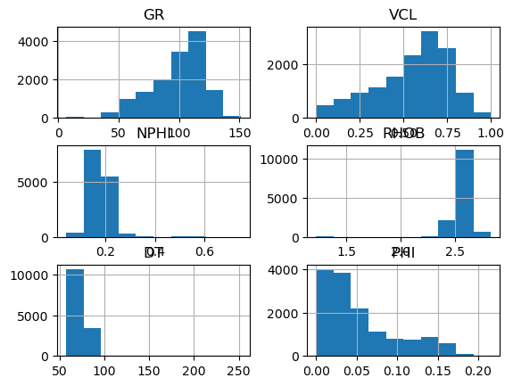

```python
"""
Training set distribution
"""
X_train.hist()

plt.show()
plt.tight_layout()
```

```python
X_train.head()
```

| Depth | GR | VCL | NPHI | RHOB | DT | PHI |
| --- | --- | --- | --- | --- | --- | --- |
| 3296.354004 | 126.943901 | 0.831338 | 0.2512 | 2.5921 | 82.245697 | 0.004070 |
| 3234.817139 | 112.288002 | 0.615394 | 0.2202 | 2.6274 | 78.447502 | 0.038323 |
| 3714.842773 | 114.684601 | 0.716683 | 0.1896 | 2.6270 | 72.547997 | 0.029518 |
| 3771.007324 | 126.512100 | 0.827179 | 0.2081 | 2.6443 | 75.155701 | 0.004429 |
| 3569.760010 | 89.596199 | 0.482221 | 0.1637 | 2.5990 | 72.337502 | 0.052883 |

```python
X_test.head()
```

| Depth | GR | VCL | NPHI | RHOB | DT | PHI |
| --- | --- | --- | --- | --- | --- | --- |
| 3402.661621 | 85.862297 | 0.447249 | 0.202300 | 2.448900 | 77.836800 | 0.121601 |
| 3397.161133 | 66.826698 | 0.229800 | 0.126199 | 2.565914 | 67.495583 | 0.083900 |
| 3155.773438 | 108.640602 | 0.680281 | 0.225200 | 2.563100 | 79.418098 | 0.038920 |
| 3769.967773 | 114.992599 | 0.719589 | 0.193400 | 2.656300 | 71.833900 | 0.023565 |
| 3657.915039 | 118.039803 | 0.768800 | 0.187469 | 2.656199 | 71.946983 | 0.013400 |

```python
Y_train.head()
```

```
Depth
3296.354004    0
3234.817139    0
3714.842773    0
3771.007324    0
3569.760010    0
Name: Litho_Facies, dtype: int64
```

```python
Y_test.head()
```

```
Depth
3402.661621    1
3397.161133    1
3155.773438    0
3769.967773    0
3657.915039    0
Name: Litho_Facies, dtype: int64
```

### 2. Preprocess data

#### 2.1 Robust Scaler - Feature Transforming

Refer documentation of [Robust Scaler](https://scikit-learn.org/stable/modules/generated/sklearn.preprocessing.RobustScaler.html)

Scale features using statistics that are robust to outliers.

This Scaler removes the median and scales the data according to the quantile range (defaults to IQR: Interquartile Range). The IQR is the range between the 1st quartile (25th quantile) and the 3rd quartile (75th quantile).

Centering and scaling happen independently on each feature by computing the relevant statistics on the samples in the training set. Median and interquartile range are then stored to be used on later data using the transform method.

Standardization of a dataset is a common requirement for many machine learning estimators. Typically this is done by removing the mean and scaling to unit variance. However, outliers can often influence the sample mean / variance in a negative way. In such cases, the median and the interquartile range often give better results.

```python
"""
Robust Scaler
To extract the feature needed for transformation, use the Robust Scaler model.
"""
robust_scaler = RobustScaler()
robust_scaler.fit(X_train)
```

```
RobustScaler()
```

```python
"""
To create standardized data, transform the train dataset.
"""
X_train_scaled = robust_scaler.transform(X_train)

scaled_median = np.median(
        X_train_scaled,
        axis=0
)
scaled_iqr = np.percentile(X_train_scaled, 75, axis=0) - np.percentile(X_train_scaled, 25, axis=0)
print("Scaled median : %s " % scaled_median)
print("Scaled IQR : %s " % scaled_iqr)

print("Original median : %s " % robust_scaler.center_)
print("Original IQR : %s " % robust_scaler.scale_)
```

```
Scaled median : [ 2.40435384e-16  1.92581411e-16  2.85009646e-16  0.00000000e+00
 -1.29461871e-15  0.00000000e+00]
Scaled IQR : [1. 1. 1. 1. 1. 1.]
Original median : [1.04547348e+02 5.97407192e-01 1.75313502e-01 2.60881996e+00
 7.34389458e+01 3.83071490e-02]
Original IQR : [29.55217175  0.28825644  0.04869107  0.08402485  5.48844338  0.05700735]
```

```python
"""
Scale the test data using the metrics discovered from the practice dataset.
"""
X_test_scaled = robust_scaler.transform(X_test)

scaled_test_data = (
    np.percentile(X_test_scaled, 75, axis=0) - np.percentile(X_test_scaled, 25, axis=0)
)
print("IQR scaled test data: %s " % scaled_test_data)

median_scaled_test_data = np.median(X_test_scaled, axis=0)
print("Median scaled test data: %s" % median_scaled_test_data)
```

```
IQR scaled test data: [0.99620088 0.98707244 1.01884278 0.98661349 0.99564626 1.01094425]
Median scaled test data: [-0.00330931  0.01031236  0.01463305 -0.01213872  0.02362308  0.00743564]
```

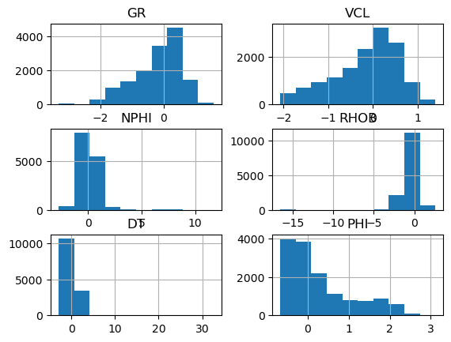

```
<function matplotlib.pyplot.tight_layout(*, pad=1.08, h_pad=None, w_pad=None, rect=None)>
```

```python
"""
Plot a graph to show the distribution of training data's histogram.
"""
pd.DataFrame(
    X_train_scaled,
    index=X_train.index,
    columns=X_test.columns
).hist()

plt.show()
plt.tight_layout
```

```python
"""
Make two dataframes for the X test and X train.
"""
X_train = pd.DataFrame(
    X_train_scaled,
    index=X_train.index,
    columns=X_test.columns
)

X_train
```

| Depth | GR | VCL | NPHI | RHOB | DT | PHI |
| --- | --- | --- | --- | --- | --- | --- |
| 3296.354004 | 0.757865 | 0.811536 | 1.558530 | -0.198989 | 1.604599 | -0.600573 |
| 3234.817139 | 0.261932 | 0.062397 | 0.921863 | 0.221125 | 0.912564 | 0.000281 |
| 3714.842773 | 0.343029 | 0.413783 | 0.293411 | 0.216366 | -0.162332 | -0.154175 |
| 3771.007324 | 0.743253 | 0.797110 | 0.673358 | 0.422256 | 0.312795 | -0.594280 |
| 3569.760010 | -0.505924 | -0.399595 | -0.238514 | -0.116870 | -0.200684 | 0.255676 |
| ... | ... | ... | ... | ... | ... | ... |
| 3363.113770 | 0.191629 | 0.308728 | 0.253962 | 0.153326 | 0.236516 | 0.092845 |
| 3526.002686 | 0.239510 | 0.314739 | 0.094196 | 0.429398 | -0.357633 | -0.291560 |
| 3740.788574 | 0.666907 | 0.724148 | 0.626121 | 0.394883 | 0.471346 | -0.552896 |
| 3607.834717 | 0.447600 | 0.514107 | 0.391992 | 0.506756 | 0.098161 | -0.330217 |
| 3458.075684 | -0.162135 | -0.316590 | -1.008676 | -0.322760 | -0.929944 | 1.721218 |

14224 rows × 6 columns

```python
X_test = pd.DataFrame(
    X_test_scaled,
    index=X_test.index,
    columns=X_test.columns
)

X_test
```

| Depth | GR | VCL | NPHI | RHOB | DT | PHI |
| --- | --- | --- | --- | --- | --- | --- |
| 3402.661621 | -0.632273 | -0.520919 | 0.554239 | -1.903246 | 0.801293 | 1.461103 |
| 3397.161133 | -1.276409 | -1.275278 | -1.008700 | -0.510638 | -1.082887 | 0.799771 |
| 3155.773438 | 0.138509 | 0.287500 | 1.024551 | -0.544123 | 1.089408 | 0.010752 |
| 3769.967773 | 0.353451 | 0.423864 | 0.371454 | 0.565072 | -0.292441 | -0.258608 |
| 3657.915039 | 0.456564 | 0.594585 | 0.249636 | 0.563872 | -0.271837 | -0.436911 |
| ... | ... | ... | ... | ... | ... | ... |
| 3212.513428 | 0.300599 | 0.460240 | 0.461820 | -0.516753 | 0.988632 | -0.534591 |
| 3607.278076 | 0.172663 | 0.288260 | 0.336387 | 0.361180 | -0.035149 | 0.134945 |
| 3790.937500 | 0.654421 | 0.404355 | 0.359132 | 0.175901 | -0.126893 | 1.068078 |
| 3344.161865 | -1.052374 | -0.923063 | -0.569170 | -1.725918 | 0.325713 | 1.326068 |
| 3775.605225 | 0.690506 | 0.431792 | 0.585046 | 0.554361 | -0.460704 | -0.616649 |

6096 rows × 6 columns

#### 2.2 Isolation Forest - Outlier Detection

```python
"""
Model training
"""
# Forest isolation
isolation_forest = IsolationForest(
    n_estimators=200,
    contamination=0.08
)

# Start model training
isolation_forest = isolation_forest.fit(X_train)
```

```python
"""
Model predicting
"""
X_train_predict = isolation_forest.predict(X_train)
X_train["Predict"] = X_train_predict
X_train["Predict"] = X_train["Predict"].astype("category")

X_train
```

| Depth | GR | VCL | NPHI | RHOB | DT | PHI | Predict |
| --- | --- | --- | --- | --- | --- | --- | --- |
| 3296.354004 | 0.757865 | 0.811536 | 1.558530 | -0.198989 | 1.604599 | -0.600573 | 1 |
| 3234.817139 | 0.261932 | 0.062397 | 0.921863 | 0.221125 | 0.912564 | 0.000281 | 1 |
| 3714.842773 | 0.343029 | 0.413783 | 0.293411 | 0.216366 | -0.162332 | -0.154175 | 1 |
| 3771.007324 | 0.743253 | 0.797110 | 0.673358 | 0.422256 | 0.312795 | -0.594280 | 1 |
| 3569.760010 | -0.505924 | -0.399595 | -0.238514 | -0.116870 | -0.200684 | 0.255676 | 1 |
| ... | ... | ... | ... | ... | ... | ... | ... |
| 3363.113770 | 0.191629 | 0.308728 | 0.253962 | 0.153326 | 0.236516 | 0.092845 | 1 |
| 3526.002686 | 0.239510 | 0.314739 | 0.094196 | 0.429398 | -0.357633 | -0.291560 | 1 |
| 3740.788574 | 0.666907 | 0.724148 | 0.626121 | 0.394883 | 0.471346 | -0.552896 | 1 |
| 3607.834717 | 0.447600 | 0.514107 | 0.391992 | 0.506756 | 0.098161 | -0.330217 | 1 |
| 3458.075684 | -0.162135 | -0.316590 | -1.008676 | -0.322760 | -0.929944 | 1.721218 | 1 |

14224 rows × 7 columns

```python
X_train["y_train"] = Y_train
X_train = X_train[
    X_train["Predict"] == 1
]

Y_train = X_train["y_train"]
X_train = X_train.drop(
    [
        "Predict",
        "y_train"
    ],
    axis=1
)

X_train.head()
```

| Depth | GR | VCL | NPHI | RHOB | DT | PHI |
| --- | --- | --- | --- | --- | --- | --- |
| 3296.354004 | 0.757865 | 0.811536 | 1.558530 | -0.198989 | 1.604599 | -0.600573 |
| 3234.817139 | 0.261932 | 0.062397 | 0.921863 | 0.221125 | 0.912564 | 0.000281 |
| 3714.842773 | 0.343029 | 0.413783 | 0.293411 | 0.216366 | -0.162332 | -0.154175 |
| 3771.007324 | 0.743253 | 0.797110 | 0.673358 | 0.422256 | 0.312795 | -0.594280 |
| 3569.760010 | -0.505924 | -0.399595 | -0.238514 | -0.116870 | -0.200684 | 0.255676 |

```python
print(len(X_train))
print(len(Y_train))
```

```
13086
13086
```

```python
Y_train.head(5)
```

```
Depth
3296.354004    0
3234.817139    0
3714.842773    0
3771.007324    0
3569.760010    0
Name: y_train, dtype: int64
```

### 2.3 Modeling

**Multi-Layer Perceptron: A Sklearn Implementation of a Neural Network**

Refer link: https://scikit-learn.org/stable/modules/neural_networks_supervised.html#mlp-tips

```python
"""
Hyperparameter tuning

"""
from sklearn.neural_network import MLPClassifier
from sklearn.model_selection import GridSearchCV

parameters = {
    "solver": ["lbfgs"],
    "max_iter": [1000,1400],
    "alpha": 10.0 ** -np.arange(1, 2),
    "hidden_layer_sizes": [10,20]
}

MLPCla = GridSearchCV(
    MLPClassifier(),
    parameters,
    n_jobs=-1,
    refit=True,
    verbose=3
)
```

```python
MLPCla.fit(
    X_train,
    Y_train
)

print(MLPCla.best_params_)
```

```
Fitting 5 folds for each of 4 candidates, totalling 20 fits
{'alpha': 0.1, 'hidden_layer_sizes': 20, 'max_iter': 1400, 'solver': 'lbfgs'}
```

```python
"""
Model Applying
"""
MLPCla = MLPClassifier(
    solver="lbfgs",
    alpha=0.1,
    hidden_layer_sizes=(10,),
    max_iter=1000
)

MLPCla.fit(
    X_train,
    Y_train
)
```

```
MLPClassifier(alpha=0.1, hidden_layer_sizes=(10,), max_iter=1000,
              solver='lbfgs')
```

```python
accuracy_generalization = MLPCla.score(
    X_test,
    Y_test
)
accuracy_memorization = MLPCla.score(
    X_train,
    Y_train
)
print("Accuracy (generalization): {}".format(accuracy_generalization))  #Accuracy (generalization)
print("Accuracy (memorization): {}".format(accuracy_memorization))  #Accuracy (memorization)

f1_score_generalization = f1_score(
    Y_test,
    MLPCla.predict(X_test),
    average="weighted"
)
f1_score_memorization = f1_score(
    Y_train,
    MLPCla.predict(X_train),
    average="weighted"
)
print("F1_score (generalization): {}".format(f1_score_generalization))  #F1_score (generalization)
print("F1_score (memorization): {}".format(f1_score_memorization))  #F1_score (memorization)
```

```
Accuracy (generalization): 0.8579396325459318
Accuracy (memorization): 0.8720770288858322
F1_score (generalization): 0.8571619389087989
F1_score (memorization): 0.8699881808742319
```

**Observations:**

- We can improve the accuracy and F1_score metrics by applying the hyperparameter tweaking method.
- Visit [this website](https://medium.com/analytics-vidhya/accuracy-vs-f1-score-6258237beca2) for additional details on the comparison between Accuracy and F1_score.

### 2.4 Implementation (Projections for a new dataset)

```python
X = well_checking.reset_index().drop(
    [
        "Litho_Facies",
        "FACIES",
        "Formation",
        "Well Name",
        "Litho_Facies_Label",
        "Depth"
    ],
    axis = 1)
Y_test = well_checking["Litho_Facies"]

X.head()
```

|  | GR | VCL | NPHI | RHOB | DT | PHI |
| --- | --- | --- | --- | --- | --- | --- |
| 0 | 68.623596 | 0.2317 | 0.2013 | 2.3407 | 81.306198 | 0.1817 |
| 1 | 65.348801 | 0.1949 | 0.1858 | 2.3346 | 80.998299 | 0.1836 |
| 2 | 67.949402 | 0.2242 | 0.1912 | 2.3285 | 81.571404 | 0.1845 |
| 3 | 68.708702 | 0.2327 | 0.2007 | 2.3377 | 80.729202 | 0.1826 |
| 4 | 62.979198 | 0.1683 | 0.2009 | 2.3591 | 80.173500 | 0.1817 |

```python
X_test
```

| Depth | GR | VCL | NPHI | RHOB | DT | PHI |
| --- | --- | --- | --- | --- | --- | --- |
| 3402.661621 | -0.632273 | -0.520919 | 0.554239 | -1.903246 | 0.801293 | 1.461103 |
| 3397.161133 | -1.276409 | -1.275278 | -1.008700 | -0.510638 | -1.082887 | 0.799771 |
| 3155.773438 | 0.138509 | 0.287500 | 1.024551 | -0.544123 | 1.089408 | 0.010752 |
| 3769.967773 | 0.353451 | 0.423864 | 0.371454 | 0.565072 | -0.292441 | -0.258608 |
| 3657.915039 | 0.456564 | 0.594585 | 0.249636 | 0.563872 | -0.271837 | -0.436911 |
| ... | ... | ... | ... | ... | ... | ... |
| 3212.513428 | 0.300599 | 0.460240 | 0.461820 | -0.516753 | 0.988632 | -0.534591 |
| 3607.278076 | 0.172663 | 0.288260 | 0.336387 | 0.361180 | -0.035149 | 0.134945 |
| 3790.937500 | 0.654421 | 0.404355 | 0.359132 | 0.175901 | -0.126893 | 1.068078 |
| 3344.161865 | -1.052374 | -0.923063 | -0.569170 | -1.725918 | 0.325713 | 1.326068 |
| 3775.605225 | 0.690506 | 0.431792 | 0.585046 | 0.554361 | -0.460704 | -0.616649 |

6096 rows × 6 columns

```python
Y_test
```

```
Depth
3100.072754    1
3100.202148    1
3100.331543    1
3100.460693    1
3100.590088    1
              ..
3795.709473    1
3795.795166    1
3795.881104    1
3795.967041    1
3796.052979    1
Name: Litho_Facies, Length: 6872, dtype: int64
```

```python
"""
To scale the dataset
"""
X_test = robust_scaler.transform(X)
X_test = pd.DataFrame(
    X_test,
    index=X.index,
    columns=X.columns
)

X_test.head()
```

|  | GR | VCL | NPHI | RHOB | DT | PHI |
| --- | --- | --- | --- | --- | --- | --- |
| 0 | -1.215604 | -1.268687 | 0.533701 | -3.190962 | 1.433421 | 2.515340 |
| 1 | -1.326419 | -1.396351 | 0.215368 | -3.263558 | 1.377322 | 2.548669 |
| 2 | -1.238418 | -1.294706 | 0.326271 | -3.336155 | 1.481742 | 2.564456 |
| 3 | -1.212725 | -1.265218 | 0.521379 | -3.226665 | 1.328292 | 2.531127 |
| 4 | -1.406602 | -1.488630 | 0.525487 | -2.971976 | 1.227043 | 2.515340 |

```python
def facies_plot_comparation(logs, compare, facies_colors):

    logs = logs.sort_values(by="Depth")
    facies_cmap = colors.ListedColormap(
        facies_colors[0:len(facies_colors)],
        "indexed"
    )

    ztop=3100
    zbot=3800

    cluster1 = np.repeat(
        np.expand_dims(well_checking["Litho_Facies"].values, 1),
        100,
        1
    )
    cluster2 = np.repeat(
        np.expand_dims(well_checking[compare].values, 1),
        100,
        1
    )
    f, ax = plt.subplots(
        nrows=1,
        ncols=7,
        figsize=(9, 12)
    )
    ax[0].plot(
        well_checking.GR,
        well_checking.Depth,
        "-g"
    )
    ax[1].plot(
        well_checking.VCL,
        well_checking.Depth,
        "-")
    ax[2].plot(
        well_checking.NPHI,
        well_checking.Depth,
        "-",
        color="0.5"
    )
    ax[3].plot(
        well_checking.RHOB,
        well_checking.Depth,
        "-",
        color="r"
    )
    ax[4].plot(
        well_checking.DT,
        well_checking.Depth,
        "-",
        color="black"
    )
    im1 = ax[5].imshow(
        cluster1,
        interpolation="none",
        aspect="auto",
        cmap=facies_cmap,
        vmin=0,
        vmax=1
    )
    im2 = ax[6].imshow(
        cluster2,
        interpolation="none",
        aspect="auto",
        cmap=facies_cmap,
        vmin=0,
        vmax=1
    )

    divider = make_axes_locatable(ax[6])
    cax = divider.append_axes(
        "right",
        size="20%",
        pad=0.05
    )
    cbar = plt.colorbar(
        im2,
        cax=cax
    )
    cbar.set_label(
        (17*" ").join([" Sand "," Shale "]))
    cbar.set_ticks(range(0,1))
    cbar.set_ticklabels("")

    for i in range(len(ax)-2):
        ax[i].set_ylim(
            ztop,
            zbot
        )
        ax[i].invert_yaxis()
        ax[i].grid()
        ax[i].locator_params(
            axis="x",
            nbins=3
        )

    ax[0].set_xlabel("GR")
    ax[0].set_xlim(0,150)

    ax[1].set_xlabel("VCL")
    ax[1].set_xlim(0,1)

    ax[2].set_xlabel("NPHI")
    ax[2].set_xlim(0.1,0.3)

    ax[3].set_xlabel("RHOB")
    ax[3].set_xlim(2,3)

    ax[4].set_xlabel("DT")
    ax[4].set_xlim(60,150)

    ax[5].set_xlabel("Litho_Facies")
    ax[5].set_xlim(0,1)

    ax[6].set_xlabel(compare)
    ax[6].set_xlim(0,1)

    ax[1].set_yticklabels([])
    ax[2].set_yticklabels([])
    ax[3].set_yticklabels([])
    ax[4].set_yticklabels([])
    ax[5].set_yticklabels([])
    ax[5].set_xticklabels([])
    ax[6].set_xticklabels([])
```

```python
well_checking.reset_index(inplace=True)
```

### 2.5 (Sklearn Supervised Neural Network Models) Multi-Layer Perceptron

```python
"""
Model predicting
"""
Y_pred = MLPCla.predict(X_test)
well_checking["Prediction"] = Y_pred
well_checking.tail(100)
```

|  | Depth | Litho_Facies | Formation | Well Name | GR | VCL | NPHI | RHOB | DT | FACIES | PHI | Litho_Facies_Label | Prediction |
| --- | --- | --- | --- | --- | --- | --- | --- | --- | --- | --- | --- | --- | --- |
| 6772 | 3787.549805 | 1 | A | 4 | 61.623001 | 0.1983 | 0.1272 | 2.4344 | 73.406998 | 1 | 0.1293 | Sand | 1 |
| 6773 | 3787.635498 | 1 | A | 4 | 61.014099 | 0.1924 | 0.1229 | 2.4339 | 72.924004 | 1 | 0.1283 | Sand | 1 |
| 6774 | 3787.721680 | 1 | A | 4 | 60.157799 | 0.1842 | 0.1265 | 2.4399 | 72.998199 | 1 | 0.1282 | Sand | 1 |
| 6775 | 3787.807373 | 1 | A | 4 | 64.576897 | 0.2267 | 0.1229 | 2.4427 | 72.774200 | 1 | 0.1216 | Sand | 1 |
| 6776 | 3787.893311 | 1 | A | 4 | 64.138496 | 0.2225 | 0.1229 | 2.4400 | 72.612503 | 1 | 0.1231 | Sand | 1 |
| ... | ... | ... | ... | ... | ... | ... | ... | ... | ... | ... | ... | ... | ... |
| 6867 | 3795.709473 | 1 | A | 4 | 62.953300 | 0.2111 | 0.2028 | 2.5632 | 69.497299 | 0 | 0.1508 | Sand | 1 |
| 6868 | 3795.795166 | 1 | A | 4 | 62.953300 | 0.2111 | 0.2056 | 2.5599 | 69.582298 | 0 | 0.1536 | Sand | 1 |
| 6869 | 3795.881104 | 1 | A | 4 | 62.953300 | 0.2111 | 0.2058 | 2.5694 | 69.496300 | 0 | 0.1498 | Sand | 1 |
| 6870 | 3795.967041 | 1 | A | 4 | 62.953300 | 0.2111 | 0.2066 | 2.5688 | 69.559097 | 0 | 0.1500 | Sand | 1 |
| 6871 | 3796.052979 | 1 | A | 4 | 62.953300 | 0.2111 | 0.2033 | 2.5670 | 69.368599 | 0 | 0.1508 | Sand | 1 |

100 rows × 13 columns

```python
well_checking.shape
```

```
(6872, 13)
```

```python
well_checking.query('Prediction == 1 ').head()
```

|  | Depth | Litho_Facies | Formation | Well Name | GR | VCL | NPHI | RHOB | DT | FACIES | PHI | Litho_Facies_Label | Prediction |
| --- | --- | --- | --- | --- | --- | --- | --- | --- | --- | --- | --- | --- | --- |
| 0 | 3100.072754 | 1 | A | 4 | 68.623596 | 0.2317 | 0.2013 | 2.3407 | 81.306198 | 3 | 0.1817 | Sand | 1 |
| 1 | 3100.202148 | 1 | A | 4 | 65.348801 | 0.1949 | 0.1858 | 2.3346 | 80.998299 | 3 | 0.1836 | Sand | 1 |
| 2 | 3100.331543 | 1 | A | 4 | 67.949402 | 0.2242 | 0.1912 | 2.3285 | 81.571404 | 3 | 0.1845 | Sand | 1 |
| 3 | 3100.460693 | 1 | A | 4 | 68.708702 | 0.2327 | 0.2007 | 2.3377 | 80.729202 | 3 | 0.1826 | Sand | 1 |
| 4 | 3100.590088 | 1 | A | 4 | 62.979198 | 0.1683 | 0.2009 | 2.3591 | 80.173500 | 3 | 0.1817 | Sand | 1 |

## Result

[figure not shown]

```python
facies_plot_comparation(well_checking.reset_index(), "Prediction", f_colors)
```

```python
arr_names = [
    "Shale",
    "Sand"
]

c_report = classification_report(
    Y_test,
    Y_pred,
    target_names=arr_names
)
print("Classification Report")
print(c_report)
```

```
Classification Report
              precision    recall  f1-score   support

       Shale       0.95      0.86      0.90      4826
        Sand       0.73      0.89      0.80      2046

    accuracy                           0.87      6872
   macro avg       0.84      0.88      0.85      6872
weighted avg       0.88      0.87      0.87      6872
```

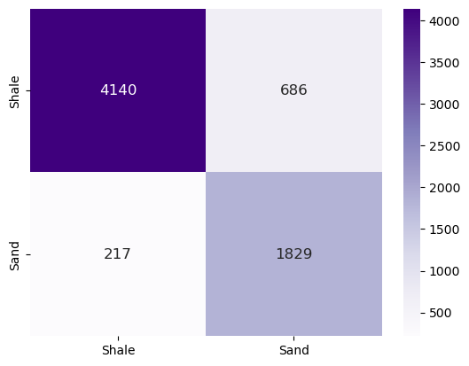

```python
"""
Matrix Confusion
"""
c_matrix = confusion_matrix(
    Y_test,
    Y_pred
)

sns.heatmap(
    c_matrix,
    annot=True,
    annot_kws={
        "size": 12
    },
    cmap="Purples",
    fmt="d",
    xticklabels=arr_names,
    yticklabels=arr_names)

plt.show()
plt.tight_layout()
```

```python
Y_pred_train = MLPCla.predict(X_train)
Y_pred_train
```

```
array([0, 1, 0, ..., 0, 0, 0], dtype=int64)
```

```python
Y_pred_test = MLPCla.predict(X_train)
Y_pred_test
```

```
array([0, 1, 0, ..., 0, 0, 0], dtype=int64)
```

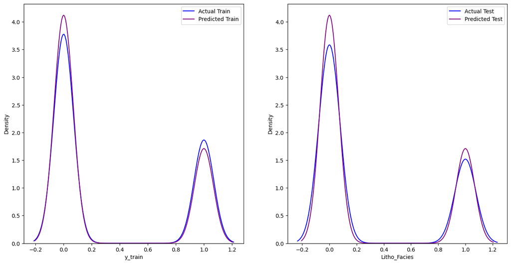

```python
plt.figure(figsize=(16,8))

plt.subplot(1, 2, 1)
ax1 = sns.distplot(
    Y_train,
    hist=False,
    color="blue",
    label="Actual Train"
)
sns.distplot(
    Y_pred_train,
    hist=False,
    color="purple",
    label="Predicted Train",
    ax=ax1
)
plt.legend()


plt.subplot(1, 2, 2)
ax2 = sns.distplot(
    Y_test,
    hist=False,
    color="blue",
    label="Actual Test"
)
sns.distplot(
    Y_pred_test,
    hist=False,
    color="purple",
    label="Predicted Test",
    ax=ax2
)
plt.legend()


plt.show()
```

**Summary**